# Start with Python - Practical exercise - Solution

## 1.1

Write a function that gets your birth year and return your age, for simplicity assume that you were born 1.1.

hint: you can use classic function inputs f(curernt_year, birth_year) or use input() method to enter the year of birth

```python
# without input method
def get_age(current_year, birth_year):
    age = current_year - birth_year
    print(age)
get_age(2022, 1980)

# with input method which asks for the keyboard input
# def get_age():
#     year_of_birth = input('Enter your birth year: ')
#     age = 2021 - int(year_of_birth)
#     print(age)
# get_age()

# or call the function without ()
# get_age
```

```
42
```

## 1.2

Write a function that takes a list of numbers and makes a new list of only the first and last elements of the given list.

```python
def list_ends(a_list):
    return [a_list[0], a_list[len(a_list)-1]]

list_ends([1,2,3,4,5])
```

```
[1, 5]
```

## 2.1

Write a function to recognize odd and even number. Depending on a number given, the function will print our whether the number is odd or even.

```python
def evenodd(num):
    mod = int(num) % 2
    if mod > 0:
        print("You picked an odd number.")
    else:
        print("You picked an even number.")
#     return num

evenodd(10)

# using input method
# def evenodd():
#     num = input("Enter a number: ")

#     mod = int(num) % 2
#     if mod > 0:
#         print("You picked an odd number.")
#     else:
#         print("You picked an even number.")
# #     return

# evenodd()
```

```
You picked an even number.
```

## 2.2

Write a function which will find all numbers divisible by 7 but are not a multiple of 5, between given range (both border limits of range included)

hint: list method append()

```python
def search_numbers(a,b):
    out =[]
    for i in range(a, b+1):
        if (i%7==0) and (i%5!=0):
            out.append(i)
    return out
search_numbers(10, 100)
```

```
[14, 21, 28, 42, 49, 56, 63, 77, 84, 91, 98]
```

## 2.3

Write a function that takes a list and returns a new list that contains all the elements of the first list minus duplicates.

hint: use sets properties

```python
def remove_duplicates(x):
    return list(set(x))
remove_duplicates([1, 1, 2, 2, 3, 3, 4, 5, 6])
```

```
[1, 2, 3, 4, 5, 6]
```

## 3

Write a Python function to compute the Euclidean distance between the points (x1, y1) and (x2, y2).

hint: use module sqrt of math package

[figure not shown]

```python
import math

def ed(p1, p2):
    distance = math.sqrt( ((p1[0]-p2[0])**2)+((p1[1]-p2[1])**2) )
    return distance
p1 = [0,0]
p2 = [3,10]
print(ed(p1, p2))
```

```
10.44030650891055
```

## 4

Write a function that obtains two vectors of arbitrary size and outputs items that are common in both vectors. Use manually entered input vectros and then also change the function to generate random input vectors.

hint: useful list method here would be append(), also package random and its module randint helps

```python
# manual entry
a = [1, 1, 2, 3, 5, 8, 13, 21, 34, 55, 89]
b = [1, 2, 3, 4, 5, 6, 7, 8, 21]

c = []
for i in b: # goes through all numbers in b
    if i in a: # checks if b[i] is in a, if True, then it adds it to c
        c.append(i)
print(c)

# random lists
import random
a = range(1, random.randint(1,30))
b = range(1, random.randint(10,40))

new_list = []
for num in a:
    if num in b:
        new_list.append(num)

print(new_list)
```

```
[1, 2, 3, 5, 8, 21]
[1, 2, 3, 4, 5, 6, 7]
```

## 5.1

Write a function that duplicates the characters in a string one by one and display result. input = 'some word', output = 'ssoommee wwoorrdd' hint: use list comprehension and join() method and * operator

```python
def dupl_ch(s):
    return ''.join([n+n for n in [*s]])

s = 'some word'
print([*s])

print(dupl_ch(s))
```

```
['s', 'o', 'm', 'e', ' ', 'w', 'o', 'r', 'd']
ssoommee  wwoorrdd
```

## 5.2

Write the function that reverts the string characters.

```python
def string_r(my_string):
  return my_string[::-1]

my_string = 'Eva can I see bees in a cave'

print(my_string)
print(string_r(my_string))
```

```
Eva can I see bees in a cave
evac a ni seeb ees I nac avE
```

## 5.3

Write a function to reverse an order of words in my_string

Hint: you can use joint(), and split() methods of string

```python
def reverse_words(my_string):
  return ' '.join(my_string.split()[::-1])
my_string = 'Python is a great programming language'
print(reverse_words(my_string))
```

```
language programming great a is Python
```

### 6

Write a function that swaps values of two variables

hint: use a native approach with temporary variables and then use tuple data type

```python
def swap(a,b):
  temp = a
  a = b
  b = temp
  return a,b
print(swap(10,20))

def swap(a,b):
    (a,b) = (b,a)
    return a, b
print(swap(10,20))

def swap(a,b):
  return b,a
print(swap(10,20))
```

```
(20, 10)
(20, 10)
(20, 10)
```

### 7

Write a function that counts the number of occurrences of a letter in a string. Input will be a string and a letter to count, output the number occurences of a given letter

```python
def count_letter_occurences(my_string, my_letter):
    count = 0
    for char in my_string:
        if char == my_letter:
            count += 1
    return(my_letter, count)

count_letter_occurences("Mississippi", 'i')
```

```
('i', 4)
```

### 8.1

Write a function to form a frequency table of the letters in the string, that is, how many times each letter appears

Output for word Mississippi => {'M': 1, 'i': 4, 's': 4, 'p': 2}

hint:

- you can itterate through your string and create dictionary for each letter in your string
- use dictionary method get()

```python
def countletters(my_string):
    letter_counts = {} # define empty dictionary
    for letter in my_string: # loop through letters in string

        letter_counts[letter] = letter_counts.get(letter, 0) + 1 # for each letter, use letter as a key and add a value of count for that letter, check the get() syntax

    return letter_counts
letter_counts = countletters('Mississippi')
letter_counts
```

```
{'M': 1, 'i': 4, 's': 4, 'p': 2}
```

### 8.2

Sort the results of previous function in alphabetical order hint: usable dictionary method items(), and list methods sort()

```python
letter_items = list(letter_counts.items())
letter_items.sort()
print(letter_items)
# note: sort assumes capital first
```

```
[('M', 1), ('i', 4), ('p', 2), ('s', 4)]
```

## 9

Write one line of Python that takes a list and makes a new list that has only the even elements of this list in it.

```python
a = [1, 4, 9, 16, 25, 36, 49, 64, 81, 100]
b = [number for number in a if number % 2 == 0]
print(b)
```

```
[4, 16, 36, 64, 100]
```

## 10

Write a function to ask for anumner and to check if it is a prime and print corresponding result.

Hint: Prime is divisible only by 1 and itself.

```python
def is_prime(n):

    # first get a list of dividers with 0 remainders
    # using list comprehension
    dividers = [x for x in range(2, n) if n % x == 0]
    # print(dividers)

#     #using for loops
#     dividers = []
#     for x in range(2,n):
#         if n % x == 0:
#             dividers.append(x)
#     print(dividers)

    if n > 1:
        if len(dividers) == 0:
            print (n, '...is prime')
        else:
            print (n, '...is NOT prime')
    else:
        print (n, '...is NOT prime')

# calling the function
given_number = 242
is_prime(given_number)
```

```
242 ...is NOT prime
```

## Homework

### 1

Write function to compute RMSE between two vectors:

y_actual = [1,2,3,4,5] and y_predicted = [1.6,2.5,2.9,3,4.1]

Try following approaches:

1:using lists and for loop

2:using numpy package and np.square(), np.subtract(), math.sqrt(), and mean() methods

RMSE = sqrt(sum ( (y_actual-y_predicted)^2) / N ), where N is a lenght of input vectors Hint: RMSE = 0.6971370023173351

```python
import math
import numpy as np
y_actual = [1,2,3,4,5]
y_predicted = [1.6,2.5,2.9,3,4.1]

e = 0
for i in range(len(y_actual)):
  e = e + (y_actual[i] - y_predicted[i])**2
e = (e/len(y_actual))**(1/2)

print("Root Mean Square Error method 1:")
print(e, '\n')

def get_rmse(y_actual, y_predicted):
  MSE = np.square(np.array(y_actual) - np.array(y_predicted)).mean()
  RMSE = math.sqrt(MSE)
  return RMSE

print("Root Mean Square Error method 2:")
print(get_rmse(y_actual, y_predicted))
```

```
Root Mean Square Error method 1:
0.6971370023173351

Root Mean Square Error method 2:
0.6971370023173351
```

### 2

Write a Python program to plot several lines with different format styles in one command using arrays.

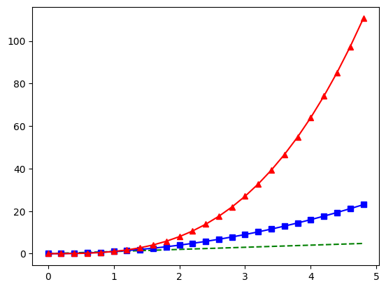

```python
import numpy as np
import matplotlib.pyplot as plt

# Sampled time at 200ms intervals
t = np.arange(0., 5., 0.2)

# green dashes, blue squares and red triangles
plt.plot(t, t, 'g--', t, t**2, 'bs-', t, t**3, 'r^-')
plt.show()
```

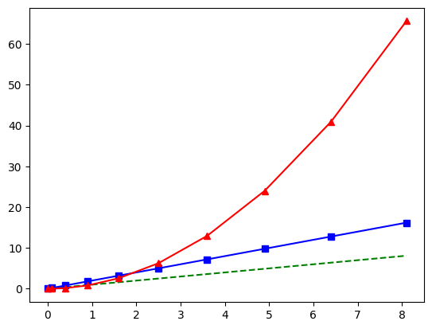

```python
# another way of doing the same plot
# import numpy as np
# import matplotlib.pyplot as plt # no need to import again if the previous cell is run before this one

l1 = [n*n for n in range(10)]
a1 = np.array(l1)/10
plt.plot(a1, a1, 'g--', a1, 2*a1, 'bs-', a1, a1**2, 'r^-')
plt.show()
```

```python
# this is how to mount google drive to be usable and reachable as data storage
from google.colab import drive
drive.mount('/content/drive')
```

```python
# convert colab nb to html
%%shell
jupyter-nbconvert --to html /content/drive/MyDrive/Teaching/MLP/2023_autumn/W0-Solutions.ipynb
```